# Lab Six: CNNs

#### Member : Yang Shen

# Metric

This dataset I used in lab2. https://www.kaggle.com/vipoooool/new-plant-diseases-dataset

The third party who interested in this result is seeds company. They sell millions of seeds over a year. The quality of seeds is important for the company. Seeds company usually sell some anti-disease seeds in the market. But the performance of anti-disease seeds needs to keep tracking. Farmers can upload the photos to seeds company for daily bases. The seeds company can use our method to find out the category of leaves and what disease the crops got, or crops are healthy. So that they can give advice about how to deal with sick crops to farmers. Also, they can monitor the performance of their seeds.

The performance of our model needs to be accurate in order to find out which disease and plant it is. My metric is accuracy. Becasue my task is prediciton which class the plant is. The accuracy directly reflect what is the ratio of my correction prediction. All other false positive and false negative are meaningless, because if it get wrong, the picture need to check by human. The only correct classification can save time from human checking.

```python
#https://www.youtube.com/watch?v=j-3vuBynnOE
%matplotlib inline
from matplotlib import pyplot as plt
import pandas as pd
import numpy as np
import os
import cv2
datadir = "C:/Users/jacks/Desktop/plant"
Category = ["Apple_Black_rot","Apple_healthy","Grape_Black_rot","Grape_healthy","Pepper_Bacterial_spot","Pepper_healthy","Potato_healthy","Potato_Late_blight","Tomato_Bacterial_spot","Tomato_healthy"]

for i in Category:
    path = os.path.join(datadir, i) #path to the leaf data
    for img in os.listdir(path):
        img_array = cv2.imread(os.path.join(path,img), cv2.IMREAD_GRAYSCALE)# read all the leaves file from each sub file

        break   #show some images not all
```

```
original size of the images: (256, 256)
==================================
```

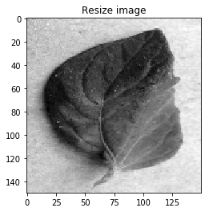

```python
print('original size of the images:',img_array.shape)
print('==================================')
#show the resize of images
imagesize = 150
resize_array = cv2.resize(img_array, (imagesize,imagesize))
plt.imshow(resize_array, cmap = 'gray')
plt.title('Resize image')
plt.show()
```

```python
images=[] #just reimport the data from the files and resize the images as well
def creat_data():
    for i in Category:
        path = os.path.join(datadir, i)
        class_num = Category.index(i) #set a index for the column which will help me to set the names for different leaves
        for img in os.listdir(path):
            img_array = cv2.imread(os.path.join(path,img), cv2.IMREAD_GRAYSCALE)
            resize_array = cv2.resize(img_array, (imagesize,imagesize))
            images.append([resize_array, class_num])# append the 1-d images data and the column index

creat_data()
```

```python
#create the array contain the images data with 1-D image features
X = []
y = []
#seprate the 1-d images data and column values
for features, label in images:
    X.append(features)
    y.append(label)

names = y.copy()
#reshape the array into the correct format, which each row represent one images
X_images = np.array(X).reshape(-1,imagesize,imagesize)
X = np.array(X_images).reshape(len(images),imagesize*imagesize)

_, h, img_wh = X_images.shape
```

```python
#https://stackoverflow.com/questions/2582138/finding-and-replacing-elements-in-a-list-python
# replace the index value to the names of leaf
item_to_replace = 0
replacement_value = "Apple_Black_rot" #name of leaf
indices_to_replace = [i for i,x in enumerate(names) if x==item_to_replace]

for i in indices_to_replace:
    names[i] = replacement_value

item_to_replace = 1
replacement_value = "Apple_healthy"
indices_to_replace = [i for i,x in enumerate(names) if x==item_to_replace]

for i in indices_to_replace:
    names[i] = replacement_value

item_to_replace = 2
replacement_value = "Grape_Black_rot"
indices_to_replace = [i for i,x in enumerate(names) if x==item_to_replace]

for i in indices_to_replace:
    names[i] = replacement_value

item_to_replace = 3
replacement_value = "Grape_healthy"
indices_to_replace = [i for i,x in enumerate(names) if x==item_to_replace]

for i in indices_to_replace:
    names[i] = replacement_value

item_to_replace = 4
replacement_value = "Pepper_Bacterial_spot"
indices_to_replace = [i for i,x in enumerate(names) if x==item_to_replace]

for i in indices_to_replace:
    names[i] = replacement_value

item_to_replace = 5
replacement_value = "Pepper_healthy"
indices_to_replace = [i for i,x in enumerate(names) if x==item_to_replace]

for i in indices_to_replace:
    names[i] = replacement_value

item_to_replace = 6
replacement_value = "Potato_healthy"
indices_to_replace = [i for i,x in enumerate(names) if x==item_to_replace]

for i in indices_to_replace:
    names[i] = replacement_value

item_to_replace = 7
replacement_value = "Potato_Late_blight"
indices_to_replace = [i for i,x in enumerate(names) if x==item_to_replace]

for i in indices_to_replace:
    names[i] = replacement_value

item_to_replace = 8
replacement_value = "Tomato_Bacterial_spot"
indices_to_replace = [i for i,x in enumerate(names) if x==item_to_replace]

for i in indices_to_replace:
    names[i] = replacement_value

item_to_replace = 9
replacement_value = "Tomato_healthy"
indices_to_replace = [i for i,x in enumerate(names) if x==item_to_replace]

for i in indices_to_replace:
    names[i] = replacement_value

names = np.array(names)
y = np.array(y)
```

```python
import keras
from keras.models import Sequential
from keras.layers import Reshape
from keras.layers import Dense, Dropout, Activation, Flatten
from keras.layers import Conv2D, MaxPooling2D
from keras.preprocessing.image import ImageDataGenerator
from keras.callbacks import EarlyStopping
from keras.regularizers import l2
from keras.layers import average
from keras.models import Input, Model

keras.__version__
```

```
'2.2.4'
```

```python
from sklearn import metrics as mt
from matplotlib import pyplot as plt
from skimage.io import imshow
import seaborn as sns
%matplotlib inline

def summarize_net(net, X_test, y_test, title_text=''):
    plt.figure(figsize=(15,5))
    yhat = np.argmax(net.predict(X_test), axis=1)
    acc = mt.accuracy_score(y_test,yhat)
    cm = mt.confusion_matrix(y_test,yhat)
    cm = cm/np.sum(cm,axis=1)[:,np.newaxis]
    sns.heatmap(cm, annot=True, fmt='.2f')
    plt.title(title_text+'{:.4f}'.format(acc))
```

```python
import os
import struct
import numpy as np
from sklearn.model_selection import train_test_split

NUM_CLASSES = 10
#normalized between -0.5 and 0.5
#https://stackoverflow.com/questions/38025838/normalizing-images-in-opencv
#normalized X, between 0 and 1
X = cv2.normalize(X, None, alpha=0, beta=1, norm_type=cv2.NORM_MINMAX, dtype=cv2.CV_32F)
X = np.expand_dims(X.reshape((-1,img_wh,img_wh)), axis=3)
y_ohe = keras.utils.to_categorical(y, NUM_CLASSES)

#8/2 split here just for testing if the model is working or not. I will use kfold later
X_train, X_test, y_train, y_test = train_test_split(X, y, test_size=0.2)

# NEW: Let's start by fixing the sizes
X_train = np.expand_dims(X_train.reshape((-1,img_wh,img_wh)), axis=3)
X_test = np.expand_dims(X_test.reshape((-1,img_wh,img_wh)), axis=3)
# the image data has been resized to (samples,image_rows,image_cols,image_channels)

# and one hot encoding the output values
y_train_ohe = keras.utils.to_categorical(y_train, NUM_CLASSES)
y_test_ohe = keras.utils.to_categorical(y_test, NUM_CLASSES)


print('New Shape: Rows: %d, image size: (%d,%d,%d)' % (X_train.shape[0], X_train.shape[1], X_train.shape[2], X_train.shape[3] ))
```

```
New Shape: Rows: 3384, image size: (150,150,1)
```

# Dividing training and testing

I will use k-fold becasue I only have 4300 rows in my dataset. I think 4300 is not enough to represent the features of dataset. I used 5 fold StratifiedKFold, because I need to use cross validation method and also I want all my plants have the same ratio in each fold. I used both 80/20 and StratifiedKFold as I need. 80/20 split is just for testing the model if it work.

```
(3384, 150, 150, 1)
```

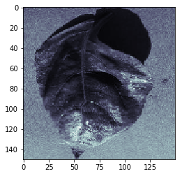

```python
print(X_train.shape)
plt.subplot(1,1,1)
plt.imshow(X_train[1].squeeze(),cmap='bone')
plt.show()
```

# Data expansion

```python
#https://keras.io/preprocessing/image/
classes = ['Apple_Black_rot',
           'Apple_healthy',
           'Grape_Black_rot',
           'Grape_healthy',
           'Pepper_Bacterial_spot',
           'Pepper_healthy',
           'Potato_healthy',
           'Potato_Late_blight',
           'Tomato_Bacterial_spot',
           'Tomato_healthy']

datagen = ImageDataGenerator(featurewise_center=False,#Set input mean to 0 over the dataset No
    samplewise_center=False,#Set each sample mean to 0. No
    featurewise_std_normalization=False,#Divide inputs by std of the dataset,i already normalized my self
    samplewise_std_normalization=False,#i already normalized my self
    zca_whitening=False,#no need to Apply ZCA whitening.
    rotation_range=5, # used, Int. Degree range for random rotations. the dataset is leaves, so rotation is useful
    width_shift_range=0.1, # used, Float (fraction of total width). leave shift width is still leave,
    height_shift_range=0.1, # used,  Float (fraction of total height). leave shift height is still leave,
                             #changing width and height is useful, leave is still leave.
    shear_range=0., # Float. Shear Intensity, No shear, prevent to cut important part.
    zoom_range=0.,#No
    channel_shift_range=0.,
    fill_mode='nearest',#Points outside the boundaries of the input are filled, useful here, fill the picture
    cval=0.,
    horizontal_flip=True,#horizontal flip a leave is still leave, yes
    vertical_flip=True,#vertical flip a leave is still leave, yes, the leave have unique shape to reconized, not like t-shirt
    rescale=None)# no rescale

datagen.fit(X_train)

idx = 0
```

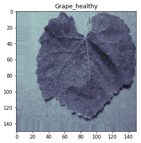

```python
tmps = datagen.flow(X_train, y_train_ohe, batch_size=1)

for tmp in tmps:
    imshow(tmp[0].squeeze(),cmap='bone')
    plt.title(classes[np.argmax(tmp[1])])
    break
```

# Model1 3X3 kernal size

```python
# what if we just want to use the validation data??
from keras.callbacks import EarlyStopping
from keras.regularizers import l2
l2_lambda = 0.0001


def create_cnn1():
    # Use Kaiming He to regularize ReLU layers: https://arxiv.org/pdf/1502.01852.pdf
    # Use Glorot/Bengio for linear/sigmoid/softmax: http://proceedings.mlr.press/v9/glorot10a/glorot10a.pdf
    cnn1 = Sequential()

    cnn1.add(Conv2D(filters=32,
                   input_shape = (img_wh,img_wh,1),
                   kernel_size=(3,3),
                   kernel_initializer='he_uniform',
                   kernel_regularizer=l2(l2_lambda),
                   padding='same',
                   activation='relu',
                   data_format="channels_last")) # more compact syntax

    cnn1.add(Conv2D(filters=32,
               kernel_size=(3,3),
               kernel_initializer='he_uniform',
               kernel_regularizer=l2(l2_lambda),
               padding='same',
               activation='relu',data_format="channels_last"))
    cnn1.add(MaxPooling2D(pool_size=(2, 2), data_format="channels_last"))

    cnn1.add(Conv2D(filters=64,
               input_shape = (img_wh,img_wh,1),
               kernel_size=(3,3),
               kernel_initializer='he_uniform',
               kernel_regularizer=l2(l2_lambda),
               padding='same',
               activation='relu',data_format="channels_last")) # more compact syntax

    cnn1.add(Conv2D(filters=64,
               kernel_size=(3,3),
               kernel_initializer='he_uniform',
               kernel_regularizer=l2(l2_lambda),
               padding='same',
               activation='relu'))
    cnn1.add(MaxPooling2D(pool_size=(2, 2), data_format="channels_last"))

    cnn1.add(Conv2D(filters=128,
               input_shape = (img_wh,img_wh,1),
               kernel_size=(3,3),
               kernel_initializer='he_uniform',
               kernel_regularizer=l2(l2_lambda),
               padding='same',
               activation='relu',data_format="channels_last")) # more compact syntax

    cnn1.add(Conv2D(filters=128,
               kernel_size=(3,3),
               kernel_initializer='he_uniform',
               kernel_regularizer=l2(l2_lambda),
               padding='same',
               activation='relu',data_format="channels_last"))


    # add one layer on flattened output

    cnn1.add(Flatten())
    cnn1.add(Dropout(0.25)) # add some dropout for regularization after conv layers
    cnn1.add(Dense(128,
              activation='relu',
              kernel_initializer='he_uniform',
              kernel_regularizer=l2(l2_lambda)
           ))
    cnn1.add(Dropout(0.5)) # add some dropout for regularization, again!
    cnn1.add(Dense(NUM_CLASSES,
                  activation='softmax',
                  kernel_initializer='glorot_uniform',
                  kernel_regularizer=l2(l2_lambda)
                 ))

    cnn1.compile(loss='categorical_crossentropy', # 'categorical_crossentropy' 'mean_squared_error'
                  optimizer='rmsprop', # 'adadelta' 'rmsprop'
                  metrics=['accuracy'])
    return cnn1

cnn1 = create_cnn1()
```

[output not shown]

```python
# the flow method yields batches of images indefinitely, with the given transofmrations
history1 = cnn1.fit_generator(datagen.flow(X_train, y_train_ohe, batch_size=128),
                  steps_per_epoch=int(len(X_train)/128), # how many generators to go through per epoch
                  epochs=50, verbose=1,
                  validation_data=(X_test,y_test_ohe),
                  callbacks=[EarlyStopping(monitor='val_loss', patience=4)]
                 )
```

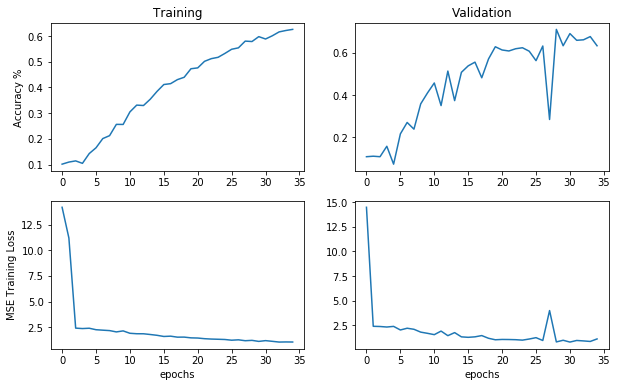

```python
from matplotlib import pyplot as plt

%matplotlib inline

plt.figure(figsize=(10,6))
plt.subplot(2,2,1)
plt.plot(history1.history['acc'])

plt.ylabel('Accuracy %')
plt.title('Training')
plt.subplot(2,2,2)
plt.plot(history1.history['val_acc'])
plt.title('Validation')

plt.subplot(2,2,3)
plt.plot(history1.history['loss'])
plt.ylabel('MSE Training Loss')
plt.xlabel('epochs')

plt.subplot(2,2,4)
plt.plot(history1.history['val_loss'])
plt.xlabel('epochs')
```

For train vs loss, I think it converge, the line reach the bottom. For validation, the line is boucing at 27 epochs. But in general, they converge.

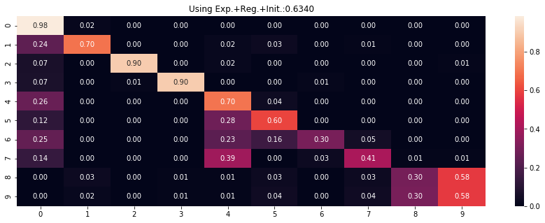

```python
#   0-  Apple_Black_rot',
#   1-  Apple_healthy',
#   2-  Grape_Black_rot',
#   3-  Grape_healthy',
#   4-  Pepper_Bacterial_spot',
#   5-  Pepper_healthy',
#   6-  Potato_healthy',
#   7-  Potato_Late_blight',
#   8-  Tomato_Bacterial_spot',
#   9-  Tomato_healthy']

summarize_net(cnn1, X_test, y_test, title_text='Using Exp.+Reg.+Init.:')
```

```python
#https://scikit-learn.org/stable/modules/generated/sklearn.model_selection.StratifiedKFold.html#sklearn.model_selection.StratifiedKFold.split
#https://github.com/Thakugan/machine-learning-notebooks/blob/master/6-wide-and-deep-networks/mushroom-hunting.ipynb
#I used this in last lab, just modified to new version
from sklearn.model_selection import StratifiedKFold
num_folds = 5

acc_scores1 =[]
skf1 = StratifiedKFold(n_splits=num_folds, shuffle=True)
for i, (train, test) in enumerate(skf1.split(X, y)):#here I used corss validation on my model

    cnn1 = create_cnn1()
    #doing modeling same as above, without for loop

    cnn1.fit_generator(datagen.flow(X_train, y_train_ohe, batch_size=128),
                  steps_per_epoch=int(len(X_train)/128), # how many generators to go through per epoch
                  epochs=50, verbose=1,
                  validation_data=(X_test,y_test_ohe),
                  callbacks=[EarlyStopping(monitor='val_loss', patience=4)]
                 )
#this is just what i do without cross validation
    yhat = np.argmax(cnn1.predict(X_test), axis=1)

    acc_score1 = mt.accuracy_score(y_test, yhat)
    acc_scores1.append(acc_score1)#append all acc for k-fold
    print("Accuracy: ", acc_score1)
print(acc_scores1)
```

```
WARNING:tensorflow:From D:\APP\conda\lib\site-packages\tensorflow\python\ops\math_ops.py:3066: to_int32 (from tensorflow.python.ops.math_ops) is deprecated and will be removed in a future version.
Instructions for updating:
Use tf.cast instead.
Accuracy:  0.7426210153482881
Accuracy:  0.5584415584415584
Accuracy:  0.5950413223140496
Accuracy:  0.680047225501771
Accuracy:  0.5489964580873672
[0.7426210153482881, 0.5584415584415584, 0.5950413223140496, 0.680047225501771, 0.5489964580873672]
```

# Model1 2X2 kernal size

```python
# what if we just want to use the validation data??
from keras.callbacks import EarlyStopping
from keras.regularizers import l2
l2_lambda = 0.0001


def create_cnn2():
    # Use Kaiming He to regularize ReLU layers: https://arxiv.org/pdf/1502.01852.pdf
    # Use Glorot/Bengio for linear/sigmoid/softmax: http://proceedings.mlr.press/v9/glorot10a/glorot10a.pdf
    cnn2 = Sequential()

    cnn2.add(Conv2D(filters=32,
                   input_shape = (img_wh,img_wh,1),
                   kernel_size=(2,2),
                   kernel_initializer='he_uniform',
                   kernel_regularizer=l2(l2_lambda),
                   padding='same',
                   activation='relu',
                   data_format="channels_last")) # more compact syntax

    cnn2.add(Conv2D(filters=32,
               kernel_size=(2,2),
               kernel_initializer='he_uniform',
               kernel_regularizer=l2(l2_lambda),
               padding='same',
               activation='relu',data_format="channels_last"))
    cnn2.add(MaxPooling2D(pool_size=(2, 2), data_format="channels_last"))

    cnn2.add(Conv2D(filters=64,
               input_shape = (img_wh,img_wh,1),
               kernel_size=(2,2),
               kernel_initializer='he_uniform',
               kernel_regularizer=l2(l2_lambda),
               padding='same',
               activation='relu',data_format="channels_last")) # more compact syntax

    cnn2.add(Conv2D(filters=64,
               kernel_size=(2,2),
               kernel_initializer='he_uniform',
               kernel_regularizer=l2(l2_lambda),
               padding='same',
               activation='relu'))
    cnn2.add(MaxPooling2D(pool_size=(2, 2), data_format="channels_last"))

    cnn2.add(Conv2D(filters=128,
               input_shape = (img_wh,img_wh,1),
               kernel_size=(2,2),
               kernel_initializer='he_uniform',
               kernel_regularizer=l2(l2_lambda),
               padding='same',
               activation='relu',data_format="channels_last")) # more compact syntax

    cnn2.add(Conv2D(filters=128,
               kernel_size=(2,2),
               kernel_initializer='he_uniform',
               kernel_regularizer=l2(l2_lambda),
               padding='same',
               activation='relu',data_format="channels_last"))


    # add one layer on flattened output

    cnn2.add(Flatten())
    cnn2.add(Dropout(0.25)) # add some dropout for regularization after conv layers
    cnn2.add(Dense(128,
              activation='relu',
              kernel_initializer='he_uniform',
              kernel_regularizer=l2(l2_lambda)
           ))
    cnn2.add(Dropout(0.5)) # add some dropout for regularization, again!
    cnn2.add(Dense(NUM_CLASSES,
                  activation='softmax',
                  kernel_initializer='glorot_uniform',
                  kernel_regularizer=l2(l2_lambda)
                 ))

    cnn2.compile(loss='categorical_crossentropy', # 'categorical_crossentropy' 'mean_squared_error'
                  optimizer='rmsprop', # 'adadelta' 'rmsprop'
                  metrics=['accuracy'])
    return cnn2

cnn2 = create_cnn2()
```

```python
# the flow method yields batches of images indefinitely, with the given transofmrations
history2 = cnn2.fit_generator(datagen.flow(X_train, y_train_ohe, batch_size=128),
                  steps_per_epoch=int(len(X_train)/128), # how many generators to go through per epoch
                  epochs=50, verbose=1,
                  validation_data=(X_test,y_test_ohe),
                  callbacks=[EarlyStopping(monitor='val_loss', patience=4)]
                 )
```

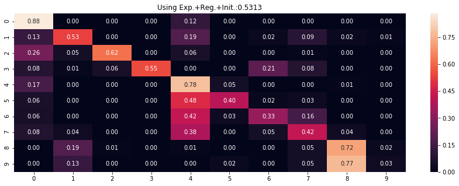

```python
#   0-  Apple_Black_rot',
#   1-  Apple_healthy',
#   2-  Grape_Black_rot',
#   3-  Grape_healthy',
#   4-  Pepper_Bacterial_spot',
#   5-  Pepper_healthy',
#   6-  Potato_healthy',
#   7-  Potato_Late_blight',
#   8-  Tomato_Bacterial_spot',
#   9-  Tomato_healthy']

summarize_net(cnn2, X_test, y_test, title_text='Using Exp.+Reg.+Init.:')
```

```python
#https://scikit-learn.org/stable/modules/generated/sklearn.model_selection.StratifiedKFold.html#sklearn.model_selection.StratifiedKFold.split
#https://github.com/Thakugan/machine-learning-notebooks/blob/master/6-wide-and-deep-networks/mushroom-hunting.ipynb
#I used this in last lab, just modified to new version
from sklearn.model_selection import StratifiedKFold
num_folds = 5

acc_scores2 =[]
skf2 = StratifiedKFold(n_splits=num_folds, shuffle=True)
for i, (train, test) in enumerate(skf2.split(X, y)):#here I used corss validation on my model

    cnn2 = create_cnn2()
    #doing modeling same as above, without for loop

    cnn2.fit_generator(datagen.flow(X_train, y_train_ohe, batch_size=128),
                  steps_per_epoch=int(len(X_train)/128), # how many generators to go through per epoch
                  epochs=50, verbose=1,
                  validation_data=(X_test,y_test_ohe),
                  callbacks=[EarlyStopping(monitor='val_loss', patience=4)]
                 )
#this is just what i do without cross validation
    yhat = np.argmax(cnn2.predict(X_test), axis=1)

    acc_score2 = mt.accuracy_score(y_test, yhat)
    acc_scores2.append(acc_score2)#append all acc for k-fold
    print("Accuracy: ", acc_score2)
print(acc_scores2)
```

```
Accuracy:  0.6682408500590319
Accuracy:  0.6233766233766234
Accuracy:  0.7024793388429752
Accuracy:  0.51357733175915
Accuracy:  0.5407319952774499
[0.6682408500590319, 0.6233766233766234, 0.7024793388429752, 0.51357733175915, 0.5407319952774499]
```

```python
t = 2.26 / np.sqrt(10)
e = (1-np.array(acc_scores1))-(1-np.array(acc_scores2))
stdtot =np.std(e)

dbar = np.mean(e)
print('model1 3X3 vs model1 2X2 acc range :',dbar-t*stdtot,dbar+t*stdtot)
```

[output not shown]

```python
from statistics import mean
print('Average accuracy for model1 3X3 ',mean(acc_scores1))
print('Average accuracy for model1 2X2 ',mean(acc_scores2))
```

[output not shown]

# Second model 3X3 kernal

```python
#second model, this one is sample cnn
def create_cnn3():
    cnn3 = Sequential()
    # let's start with an AlexNet style convolutional phase
    cnn3.add(Conv2D(filters=32,
                input_shape = (img_wh,img_wh,1),
                kernel_size=(3,3),
                padding='same',
                activation='relu', data_format="channels_last")) # more compact syntax

    # no max pool before next conv layer!!
    cnn3.add(Conv2D(filters=64,
                kernel_size=(3,3),
                padding='same',
                activation='relu')) # more compact syntax
    cnn3.add(MaxPooling2D(pool_size=(2, 2), data_format="channels_last"))


    # add one layer on flattened output
    cnn3.add(Dropout(0.25)) # add some dropout for regularization after conv layers
    cnn3.add(Flatten())
    cnn3.add(Dense(128, activation='relu'))
    cnn3.add(Dropout(0.5)) # add some dropout for regularization, again!
    cnn3.add(Dense(NUM_CLASSES, activation='softmax'))
    # Let's train the model
    cnn3.compile(loss='categorical_crossentropy', # 'categorical_crossentropy' 'mean_squared_error'
              optimizer='rmsprop', # 'adadelta' 'rmsprop'
              metrics=['accuracy'])
    return cnn3

cnn3 = create_cnn3()
```

```python
# the flow method yields batches of images indefinitely, with the given transofmrations
history3 = cnn3.fit_generator(datagen.flow(X_train, y_train_ohe, batch_size=128),
                  steps_per_epoch=int(len(X_train)/128), # how many generators to go through per epoch
                  epochs=50, verbose=1,
                  validation_data=(X_test,y_test_ohe),
                  callbacks=[EarlyStopping(monitor='val_loss', patience=4)]
                 )
```

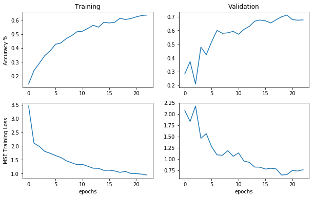

```python
from matplotlib import pyplot as plt

%matplotlib inline

plt.figure(figsize=(10,6))
plt.subplot(2,2,1)
plt.plot(history3.history['acc'])

plt.ylabel('Accuracy %')
plt.title('Training')
plt.subplot(2,2,2)
plt.plot(history3.history['val_acc'])
plt.title('Validation')

plt.subplot(2,2,3)
plt.plot(history3.history['loss'])
plt.ylabel('MSE Training Loss')
plt.xlabel('epochs')

plt.subplot(2,2,4)
plt.plot(history3.history['val_loss'])
plt.xlabel('epochs')
```

For train vs loss, I think it converge, the line reach the bottom. For validation, the line is boucing at 18 epochs. But in general, they converge.

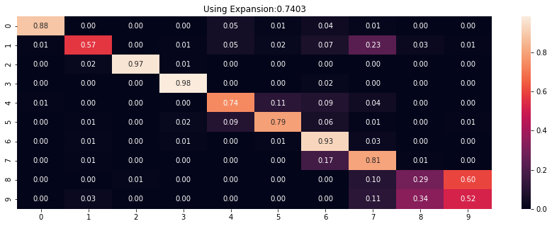

```python
#   0-  Apple_Black_rot',
#   1-  Apple_healthy',
#   2-  Grape_Black_rot',
#   3-  Grape_healthy',
#   4-  Pepper_Bacterial_spot',
#   5-  Pepper_healthy',
#   6-  Potato_healthy',
#   7-  Potato_Late_blight',
#   8-  Tomato_Bacterial_spot',
#   9-  Tomato_healthy']

summarize_net(cnn3, X_test, y_test, title_text='Using Expansion:')
```

```python
#https://scikit-learn.org/stable/modules/generated/sklearn.model_selection.StratifiedKFold.html#sklearn.model_selection.StratifiedKFold.split
#https://github.com/Thakugan/machine-learning-notebooks/blob/master/6-wide-and-deep-networks/mushroom-hunting.ipynb
#I used this in last lab, just modified to new version
from sklearn.model_selection import StratifiedKFold
num_folds = 5

acc_scores3 =[]
skf3 = StratifiedKFold(n_splits=num_folds, shuffle=True)
for i, (train, test) in enumerate(skf3.split(X, y)):#here I used corss validation on my model

    cnn3 = create_cnn3()
    #doing modeling same as above, without for loop

    cnn3.fit_generator(datagen.flow(X_train, y_train_ohe, batch_size=128),
                  steps_per_epoch=int(len(X_train)/128), # how many generators to go through per epoch
                  epochs=50, verbose=1,
                  validation_data=(X_test,y_test_ohe),
                  callbacks=[EarlyStopping(monitor='val_loss', patience=4)]
                 )
#this is just what i do without cross validation
    yhat = np.argmax(cnn3.predict(X_test), axis=1)

    acc_score3 = mt.accuracy_score(y_test, yhat)
    acc_scores3.append(acc_score3)#append all acc for k-fold
    print("Accuracy: ", acc_score3)
print(acc_scores3)
```

```
WARNING:tensorflow:From D:\APP\conda\lib\site-packages\tensorflow\python\ops\math_ops.py:3066: to_int32 (from tensorflow.python.ops.math_ops) is deprecated and will be removed in a future version.
Instructions for updating:
Use tf.cast instead.
Accuracy:  0.7284533648170012
Accuracy:  0.6446280991735537
Accuracy:  0.7095631641086186
Accuracy:  0.7485242030696576
Accuracy:  0.6635182998819362
[0.7284533648170012, 0.6446280991735537, 0.7095631641086186, 0.7485242030696576, 0.6635182998819362]
```

# Second model 2X2 kernal

```python
#second model, this one is sample cnn
def create_cnn4():
    cnn4 = Sequential()
    # let's start with an AlexNet style convolutional phase
    cnn4.add(Conv2D(filters=32,
                input_shape = (img_wh,img_wh,1),
                kernel_size=(2,2),
                padding='same',
                activation='relu', data_format="channels_last")) # more compact syntax

    # no max pool before next conv layer!!
    cnn4.add(Conv2D(filters=64,
                kernel_size=(2,2),
                padding='same',
                activation='relu')) # more compact syntax
    cnn4.add(MaxPooling2D(pool_size=(2, 2), data_format="channels_last"))


    # add one layer on flattened output
    cnn4.add(Dropout(0.25)) # add some dropout for regularization after conv layers
    cnn4.add(Flatten())
    cnn4.add(Dense(128, activation='relu'))
    cnn4.add(Dropout(0.5)) # add some dropout for regularization, again!
    cnn4.add(Dense(NUM_CLASSES, activation='softmax'))
    # Let's train the model
    cnn4.compile(loss='categorical_crossentropy', # 'categorical_crossentropy' 'mean_squared_error'
              optimizer='rmsprop', # 'adadelta' 'rmsprop'
              metrics=['accuracy'])
    return cnn4

cnn4 = create_cnn4()
```

[output not shown]

```python
# the flow method yields batches of images indefinitely, with the given transofmrations
history4 = cnn4.fit_generator(datagen.flow(X_train, y_train_ohe, batch_size=128),
                  steps_per_epoch=int(len(X_train)/128), # how many generators to go through per epoch
                  epochs=50, verbose=1,
                  validation_data=(X_test,y_test_ohe),
                  callbacks=[EarlyStopping(monitor='val_loss', patience=4)]
                 )
```

[output not shown]

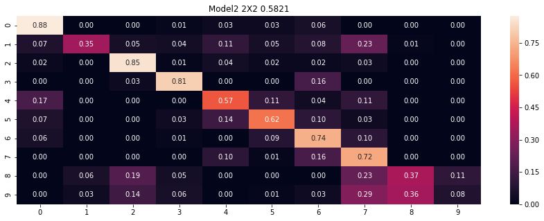

```python
#   0-  Apple_Black_rot',
#   1-  Apple_healthy',
#   2-  Grape_Black_rot',
#   3-  Grape_healthy',
#   4-  Pepper_Bacterial_spot',
#   5-  Pepper_healthy',
#   6-  Potato_healthy',
#   7-  Potato_Late_blight',
#   8-  Tomato_Bacterial_spot',
#   9-  Tomato_healthy']

summarize_net(cnn4, X_test, y_test, title_text='Model2 2X2 ')
```

```python
#https://scikit-learn.org/stable/modules/generated/sklearn.model_selection.StratifiedKFold.html#sklearn.model_selection.StratifiedKFold.split
#https://github.com/Thakugan/machine-learning-notebooks/blob/master/6-wide-and-deep-networks/mushroom-hunting.ipynb
#I used this in last lab, just modified to new version
from sklearn.model_selection import StratifiedKFold
num_folds = 5

acc_scores4 =[]
skf4 = StratifiedKFold(n_splits=num_folds, shuffle=True)
for i, (train, test) in enumerate(skf4.split(X, y)):#here I used corss validation on my model

    cnn4 = create_cnn4()
    #doing modeling same as above, without for loop

    cnn4.fit_generator(datagen.flow(X_train, y_train_ohe, batch_size=128),
                  steps_per_epoch=int(len(X_train)/128), # how many generators to go through per epoch
                  epochs=50, verbose=1,
                  validation_data=(X_test,y_test_ohe),
                  callbacks=[EarlyStopping(monitor='val_loss', patience=4)]
                 )
#this is just what i do without cross validation
    yhat = np.argmax(cnn4.predict(X_test), axis=1)

    acc_score4 = mt.accuracy_score(y_test, yhat)
    acc_scores4.append(acc_score4)#append all acc for k-fold
    print("Accuracy: ", acc_score4)
print(acc_scores4)
```

```
WARNING:tensorflow:From D:\APP\conda\lib\site-packages\tensorflow\python\ops\math_ops.py:3066: to_int32 (from tensorflow.python.ops.math_ops) is deprecated and will be removed in a future version.
Instructions for updating:
Use tf.cast instead.
Accuracy:  0.5678866587957497
Accuracy:  0.5395513577331759
Accuracy:  0.6328217237308147
Accuracy:  0.6340023612750886
Accuracy:  0.6221959858323495
[0.5678866587957497, 0.5395513577331759, 0.6328217237308147, 0.6340023612750886, 0.6221959858323495]
```

```python
t = 2.26 / np.sqrt(10)
e = (1-np.array(acc_scores3))-(1-np.array(acc_scores4))
stdtot =np.std(e)

dbar = np.mean(e)
print('model2 3X3 vs model2 2X2 acc range :',dbar-t*stdtot,dbar+t*stdtot)
```

```
model2 3X3 vs model2 2X2 acc range : -0.12504270631278086 -0.06008126062936779
```

Becasue the range is not include 0, so we can say that with 95% confident level, model2 3X3 and model2 2X2 are statisitcally different base on accuracy.

```python
from statistics import mean
print('Average accuracy for model2 3X3 ',mean(acc_scores3))
print('Average accuracy for model2 2X2 ',mean(acc_scores4))
```

[output not shown]

Base on my statistics comparision, there is different between model2 3X3 and model2 2X2, and 3X3 have higher average accuracy score. So model2 3X3 is better.

```python
t = 2.26 / np.sqrt(10)
e = (1-np.array(acc_scores1))-(1-np.array(acc_scores3))
stdtot =np.std(e)

dbar = np.mean(e)
print('model1 3X3 vs model2 3X3 acc range :',dbar-t*stdtot,dbar+t*stdtot)
```

```
model1 3X3 vs model2 3X3 acc range : 0.040028185409468404 0.10778763513362483
```

Becasue the range is not include 0, so we can say that with 95% confident level, model1 3X3 and model2 3X3 are statisitcally different base on accuracy.

```python
from statistics import mean
print('Average accuracy for model1 3X3 ',mean(acc_scores1))
print('Average accuracy for model2 3X3 ',mean(acc_scores3))
```

```
Average accuracy for model1 3X3  0.6250295159386069
Average accuracy for model2 3X3  0.6989374262101534
```

### model2 3X3 is better.

Base on my statistics comparision, there is different between model1 3X3 and model2 3X3, and model2 3X3 have higher average accuracy score. So model2 3X3 is better.

# MLP

```python
from sklearn import metrics as mt
from matplotlib import pyplot as plt
import seaborn as sns
%matplotlib inline

def compare_mlp_cnn(cnn, mlp, X_test, y_test):
    plt.figure(figsize=(15,5))
    if cnn is not None:
        yhat_cnn = np.argmax(cnn.predict(np.expand_dims(X_test, axis=1)), axis=1)
        acc_cnn = mt.accuracy_score(y_test,yhat_cnn)
        plt.subplot(1,2,1)
        cm = mt.confusion_matrix(y_test,yhat_cnn)
        cm = cm/np.sum(cm,axis=1)[:,np.newaxis]
        sns.heatmap(cm, annot=True, fmt='.2f')
        plt.title('CNN: '+str(acc_cnn))

    if mlp is not None:
        yhat_mlp = np.argmax(mlp.predict(X_test), axis=1)
        acc_mlp = mt.accuracy_score(y_test,yhat_mlp)
        plt.subplot(1,2,2)
        cm = mt.confusion_matrix(y_test,yhat_mlp)
        cm = cm/np.sum(cm,axis=1)[:,np.newaxis]
        sns.heatmap(cm,annot=True, fmt='.2f')
        plt.title('MLP: '+str(acc_mlp))
```

```python
#create the array contain the images data with 1-D image features
X = []
y = []
#seprate the 1-d images data and column values
for features, label in images:
    X.append(features)
    y.append(label)

names = y.copy()
#reshape the array into the correct format, which each row represent one images
X_images = np.array(X).reshape(-1,imagesize,imagesize)
X = np.array(X_images).reshape(len(images),imagesize*imagesize)
X = cv2.normalize(X, None, alpha=0, beta=1, norm_type=cv2.NORM_MINMAX, dtype=cv2.CV_32F)
_, h, img_wh = X_images.shape

X_train, X_test, y_train, y_test = train_test_split(X, y, test_size=0.2)
y_train_ohe = keras.utils.to_categorical(y_train, NUM_CLASSES)
y_test_ohe = keras.utils.to_categorical(y_test, NUM_CLASSES)
```

```python
from sklearn.neural_network import MLPClassifier
mlp = MLPClassifier(hidden_layer_sizes=(50,),
                       solver='sgd',
                       learning_rate_init=0.01,
                       max_iter=100,
                       random_state=1)
```

```python
%%time
mlp.fit(X_train, y_train_ohe)
#accuracy score
yhat = mlp.predict(X_test)
#https://stackoverflow.com/questions/46953967/multilabel-indicator-is-not-supported-for-confusion-matrix
print('Accuracy ',mt.accuracy_score(y_test_ohe.argmax(axis=1),yhat.argmax(axis=1)))
```

```
Accuracy  0.10153482880755609
Wall time: 2min 7s
```

```python
acc_scores5 = []


skf5 = StratifiedKFold(n_splits=num_folds, shuffle=True)
for i, (train, test) in enumerate(skf5.split(X, y)):

    mlp.fit(X_train, y_train_ohe)

    yhat = mlp.predict(X_test)
    acc_score5 = mt.accuracy_score(y_test_ohe.argmax(axis=1),yhat.argmax(axis=1))
    acc_scores5.append(acc_score5)#append all acc for k-fold
    print("Accuracy: ", acc_score5)

print(acc_scores5)
```

```
Accuracy:  0.08382526564344746
Accuracy:  0.08382526564344746
Accuracy:  0.08382526564344746
Accuracy:  0.08382526564344746
Accuracy:  0.08382526564344746
[0.08382526564344746, 0.08382526564344746, 0.08382526564344746, 0.08382526564344746, 0.08382526564344746]
```

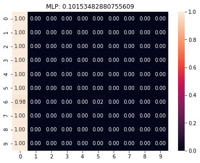

```python
compare_mlp_cnn(None,mlp,X_test,y_test)
```

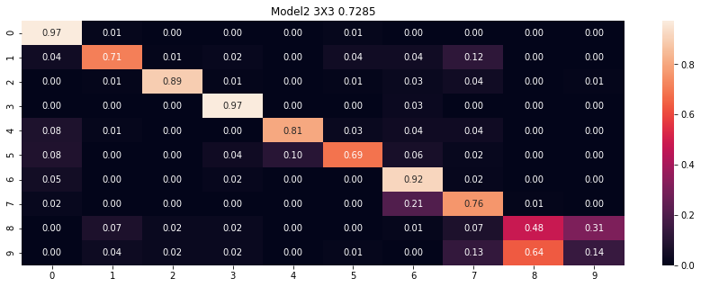

```python
summarize_net(cnn3, X_test, y_test, title_text='Model2 3X3 ')
```

```python
#https://github.com/egabrielsen/MachineLearning/blob/master/Lab08/lab8-Danh-Copy1.ipynb
#https://github.com/Nchaos/CNNs/blob/master/notebooks/Lab6_NC_CNNs.ipynb
#also modified from Dr.Larson 09 .Evaluation
def plot_roc(probas, y_true):
    plt.figure(figsize=(15,5))
    mean_tpr = 0.0
    mean_fpr = np.linspace(0, 1, 100)
    all_tpr = []

    classes = np.unique(y)#i have 10 class in total
    perclass_mean_tpr = 0.0
    roc_auc = 0
    for j in classes:
        fpr, tpr, thresholds = mt.roc_curve(y_test_ohe.argmax(axis=1), probas[:, j], pos_label=j)#generate roc curve
        perclass_mean_tpr += interp(mean_fpr, fpr, tpr)
        perclass_mean_tpr[0] = 0.0
        roc_auc += mt.auc(fpr, tpr)
        #all above just modified of Dr.Larson code
        #here plot the roc curve for each class
        plt.plot(fpr,tpr,'--',lw=.5,label='Class ROC , AUC=%0.4f' %(mt.auc(fpr, tpr)))

    perclass_mean_tpr /= len(classes)
    roc_auc /= len(classes)
    mean_tpr += perclass_mean_tpr
    #this curve is the mean roc for all class
    plt.plot(mean_fpr,perclass_mean_tpr,'-',lw=2,label='Mean Class ROC, AUC=%0.4f'
                     %(roc_auc))
    plt.legend(loc='best')
    plt.xlabel('false positive rate')
    plt.ylabel('true positive rate')
```

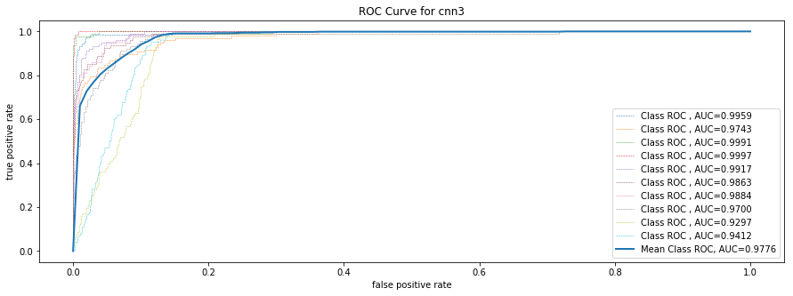

```python
probas = cnn3.predict_proba(X_test)
plot_roc(probas, y_test_ohe)
plt.title('ROC Curve for cnn3')
```

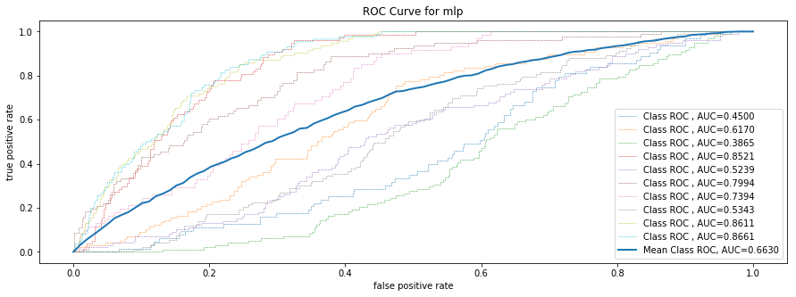

```python
probas = mlp.predict_proba(X_test)
plot_roc(probas, y_test_ohe)
plt.title('ROC Curve for mlp')
```

```python
t = 2.26 / np.sqrt(10)
e = (1-np.array(acc_scores3))-(1-np.array(acc_scores5))
stdtot =np.std(e)

dbar = np.mean(e)
print('model2 3X3 vs mlp acc range :',dbar-t*stdtot,dbar+t*stdtot)
```

```
model2 3X3 vs mlp acc range : -0.6430612670487764 -0.5871630540846354
```

Becasue the range is not include 0, so we can say that with 95% confident level, model2 3X3 and mlp are statisitcally different base on accuracy.

```python
from statistics import mean
print('Average accuracy for model1 3X3 ',mean(acc_scores3))
print('Average accuracy for mlp ',mean(acc_scores5))
```

```
Average accuracy for model1 3X3  0.6989374262101534
Average accuracy for mlp  0.08382526564344746
```

From above two ROC curve and AUC, it is clear to see that cnn model is better. It have better curve, with thresholds that false positive rate low and keep true positive rate high. Also the AUC is much more better than mlp one. Also the accuracy is way better than mlp.

# Exceptional Work - Transfer Learning With ResNet

```python
# manipulated from Keras Documentation
#  https://keras.io/applications/
from keras.applications.resnet50 import ResNet50
from keras.preprocessing import image
from keras.applications.resnet50 import preprocess_input, decode_predictions
import numpy as np
```

```python
images=[] #just reimport the data from the files and resize the images as well
def creat_data():
    for i in Category:
        path = os.path.join(datadir, i)
        class_num = Category.index(i) #set a index for the column which will help me to set the names for different leaves
        for img in os.listdir(path):
            img_array = cv2.imread(os.path.join(path,img), cv2.IMREAD_COLOR)
            resize_array = cv2.resize(img_array, (imagesize,imagesize))
            images.append([resize_array, class_num])# append the 1-d images data and the column index

creat_data()
```

```python
from keras.datasets import cifar10
from keras.utils import to_categorical

NUM_CLASSES = 10
#create the array contain the images data with 1-D image features
X = []
y = []
#seprate the 1-d images data and column values
for features, label in images:
    X.append(features)
    y.append(label)
y = np.array(y)
names = y.copy()
#reshape the array into the correct format, which each row represent one images
X_images = np.array(X).reshape(-1,imagesize,imagesize)
X = np.array(X_images).reshape(len(images),imagesize,imagesize,3)
X = cv2.normalize(X, None, alpha=0, beta=1, norm_type=cv2.NORM_MINMAX, dtype=cv2.CV_32F)
_, h, img_wh = X_images.shape

X_train, X_test, y_train, y_test = train_test_split(X, y, test_size=0.2)
# NEW: Let's start by fixing the sizes


y_train_ohe = to_categorical(y_train, NUM_CLASSES)
y_test_ohe = to_categorical(y_test, NUM_CLASSES)

print(X_train.shape)
print(y_train.shape)
print(X_test.shape)
print(y_test.shape)
```

```
(3384, 150, 150, 3)
(3384,)
(847, 150, 150, 3)
(847,)
```

```python
# from skimage.transform import resize # stupid slow function
from scipy.misc import imresize
import numpy as np


X_train_up = [imresize(X, size=(150,150,3), interp='nearest') for X in X_train]
X_train_up = np.stack(X_train_up, axis=0)
print(X_train_up.shape)

X_test_up = [imresize(X, size=(150,150,3), interp='nearest') for X in X_test]
X_test_up = np.stack(X_test_up, axis=0)
print(X_test_up.shape)
```

```
(3384, 150, 150, 3)
```

```
(847, 150, 150, 3)
```

```python
# connect new layers to the output
from keras.applications.resnet50 import ResNet50
from keras.applications.resnet50 import preprocess_input, decode_predictions

# load only convolutional layers of resnet:
if 'res_no_top' not in locals():
    res_no_top = ResNet50(weights='imagenet', include_top=False)

X = X_train_up[0]
X = np.expand_dims(X, axis=0)
X = preprocess_input(X)

%time preds = res_no_top.predict(X)
preds.shape
```

```
Wall time: 19.5 ms
```

```
(1, 5, 5, 2048)
```

```python
X_train_up = preprocess_input(X_train_up)
X_test_up = preprocess_input(X_test_up)
```

```python
# train on half the data, to save a few hours
X_train_resnet = res_no_top.predict(X_train_up)
X_test_resnet = res_no_top.predict(X_test_up)
print(X_train_resnet.shape)
```

```
(3384, 5, 5, 2048)
```

```python
from keras.layers import SeparableConv2D
from keras.layers.normalization import BatchNormalization
from keras.layers import Add, Flatten, Dense
from keras.layers import average, concatenate
from keras.models import Input, Model


# let's add a fully-connected layer
input_X = Input(shape=X_train_resnet[0].shape)
X = Flatten()(input_X)
x = Dense(200, activation='relu',kernel_initializer='he_uniform')(X)
# and a fully connected layer
predictions = Dense(NUM_CLASSES, activation='softmax', kernel_initializer='glorot_uniform')(X)

model = Model(inputs=input_X, outputs=predictions)

model.summary()
```

```
_________________________________________________________________
Layer (type)                 Output Shape              Param #
=================================================================
input_5 (InputLayer)         (None, 5, 5, 2048)        0
_________________________________________________________________
flatten_12 (Flatten)         (None, 51200)             0
_________________________________________________________________
dense_24 (Dense)             (None, 10)                512010
=================================================================
Total params: 512,010
Trainable params: 512,010
Non-trainable params: 0
_________________________________________________________________
```

```python
y_train_ohe_resnet = y_train_ohe[:X_train_resnet.shape[0]]

model.compile(optimizer='rmsprop', loss='categorical_crossentropy',metrics=['accuracy'])

model.fit(X_train_resnet,y_train_ohe_resnet,epochs=10,
          batch_size=64,verbose=1,
         validation_data=(X_test_resnet, y_test_ohe[:X_test_resnet.shape[0]]))
```

```
Train on 3384 samples, validate on 847 samples
```

```
<keras.callbacks.History at 0x2454321ce80>
```

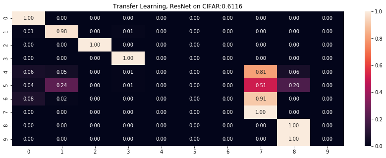

```python
summarize_net(model, X_test_resnet, y_test[:X_test_resnet.shape[0]], title_text='Transfer Learning, ResNet on CIFAR:')
```

Comparing to my best model Model2 3X3, the accuracy is 0.72, which is higher than Transfer Learning With ResNet(0.61). So my model is better base on accuracy score.